# Madrid Pollution Report

Madrid Pollution Report MBD - O17 13/12/2018

## Madrid Pollution Dataset

This report describes an analysis of the **pollution in Madrid between 2011 and 2016**.

The dataset consists in:

- 72 csv files containing hourly measures of pollutants across 24 stations,
- 1 xlsx file containing daily weather information.

The stations are located all across the city:

[interactive chart not shown]

## Packages

This analysis requires these R packages:

- Data Cleaning
  - readxl
  - tidyr
- Plotting
  - ggplot2
  - corrplot
  - GGally
  - gridExtra
  - leaflet
- Statistics
  - jtools
  - lattice
  - car
  - caret
  - MASS

These packages are installed and loaded if necessary by the main script.

## Data Preparation

The pollution and weather data are first read from the input files, formatted, combined and aggregated, into the data frame *pollution_daily_h* which provides the averaged information per day.

The dataset contains information for 12 pollutants: **NO2, SO2, O3, PM2.5, BEN, CO, EBE, NMHC, NO, PM10, TCH, TOL**.

The workflow to prepare the data is as below:

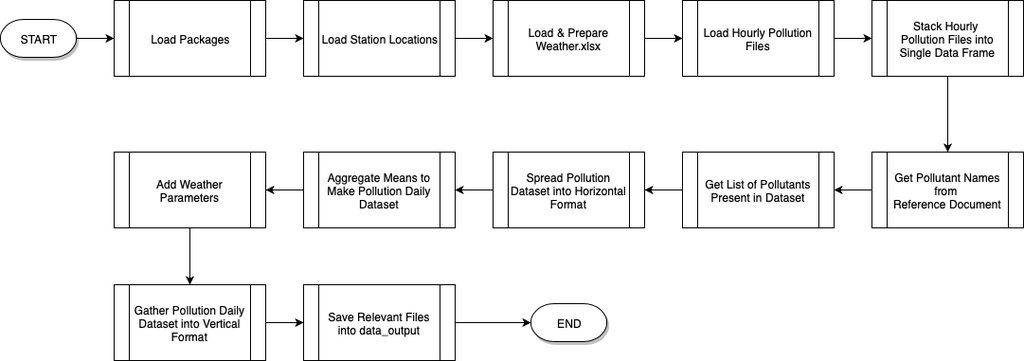

Additional variables have been added:

- *month*: the first day of the related month
- *week*: the first day of the related week
- *temp_gap*: difference between temp_min and temp_max

The data frame *pollution_daily_h* is structured as below:

```r
str(pollution_daily_h)
```

```
## 'data.frame':    2192 obs. of  22 variables:
##  $ date          : Date, format: "2011-01-01" "2011-01-02" ...
##  $ NO2           : num  41.5 48.5 63.6 46.3 51.5 ...
##  $ SO2           : num  10.71 11.93 11.91 8.84 9.51 ...
##  $ O3            : num  20.47 15.56 9.45 13.34 10.88 ...
##  $ PM2.5         : num  9.36 9.08 11.94 9.4 10.51 ...
##  $ BEN           : num  0.765 0.869 1.176 0.857 0.856 ...
##  $ CO            : num  0.372 0.453 0.532 0.367 0.395 ...
##  $ EBE           : num  0.595 0.722 1.047 0.788 1.074 ...
##  $ NMHC          : num  0.187 0.208 0.246 0.196 0.196 ...
##  $ NO            : num  16.5 28.8 71.1 27.8 36 ...
##  $ PM10          : num  13.8 13.7 21.6 14.4 15.6 ...
##  $ TCH           : num  1.43 1.62 1.62 1.46 1.52 ...
##  $ TOL           : num  1.66 2.14 3.56 2.4 3.19 ...
##  $ month         : Date, format: "2011-01-01" "2011-01-01" ...
##  $ week          : Date, format: "2010-12-27" "2010-12-27" ...
##  $ temp_avg      : num  8.3 8.6 4.2 6.5 8.9 12.2 10.9 9.8 8.4 6.9 ...
##  $ temp_max      : num  13 13 9.4 8 10 15 13 13 11 8.3 ...
##  $ temp_min      : num  3 4 -1.6 4.1 6.3 8.9 8.7 7.6 6.6 5.2 ...
##  $ precipitation : num  0 0 0 0 0 ...
##  $ humidity      : num  84 81 86 93 90 87 81 88 92 91 ...
##  $ wind_avg_speed: num  5.2 5.4 3.5 6.3 10.4 15.7 15.6 14.3 6.5 7.4 ...
##  $ temp_gap      : num  10 9 11 3.9 3.7 6.1 4.3 5.4 4.4 3.1 ...
```

```r
summary(pollution_daily_h)
```

```
##       date                 NO2               SO2               O3
##  Min.   :2011-01-01   Min.   :  7.819   Min.   : 1.679   Min.   :  3.979
##  1st Qu.:2012-07-01   1st Qu.: 26.170   1st Qu.: 3.757   1st Qu.: 30.088
##  Median :2013-12-31   Median : 35.646   Median : 5.483   Median : 49.555
##  Mean   :2013-12-31   Mean   : 38.828   Mean   : 5.889   Mean   : 47.866
##  3rd Qu.:2015-07-02   3rd Qu.: 48.122   3rd Qu.: 7.388   3rd Qu.: 65.058
##  Max.   :2016-12-31   Max.   :105.077   Max.   :17.129   Max.   :110.287
##      PM2.5             BEN               CO              EBE
##  Min.   : 2.625   Min.   :0.1514   Min.   :0.1496   Min.   :0.1028
##  1st Qu.: 7.306   1st Qu.:0.4520   1st Qu.:0.2575   1st Qu.:0.3318
##  Median :10.024   Median :0.6152   Median :0.3075   Median :0.6782
##  Mean   :11.112   Mean   :0.7392   Mean   :0.3574   Mean   :0.6789
##  3rd Qu.:13.646   3rd Qu.:0.8911   3rd Qu.:0.4058   3rd Qu.:0.8651
##  Max.   :58.556   Max.   :2.8132   Max.   :1.1792   Max.   :3.2252
##       NMHC               NO               PM10              TCH
##  Min.   :0.04319   Min.   :  2.351   Min.   :  3.618   Min.   :1.063
##  1st Qu.:0.15269   1st Qu.:  6.973   1st Qu.: 12.730   1st Qu.:1.327
##  Median :0.18694   Median : 11.814   Median : 18.556   Median :1.394
##  Mean   :0.20500   Mean   : 23.681   Mean   : 20.805   Mean   :1.421
##  3rd Qu.:0.23620   3rd Qu.: 26.178   3rd Qu.: 25.560   3rd Qu.:1.482
##  Max.   :0.66167   Max.   :214.569   Max.   :216.628   Max.   :2.412
##       TOL              month                 week
##  Min.   : 0.2667   Min.   :2011-01-01   Min.   :2010-12-27
##  1st Qu.: 1.6969   1st Qu.:2012-07-01   1st Qu.:2012-06-30
##  Median : 2.4893   Median :2013-12-16   Median :2013-12-30
##  Mean   : 3.0021   Mean   :2013-12-16   Mean   :2013-12-28
##  3rd Qu.: 3.6722   3rd Qu.:2015-07-01   3rd Qu.:2015-06-29
##  Max.   :15.6062   Max.   :2016-12-01   Max.   :2016-12-26
##     temp_avg        temp_max        temp_min      precipitation
##  Min.   :-0.50   Min.   : 3.30   Min.   :-7.000   Min.   : 0.0000
##  1st Qu.: 8.40   1st Qu.:14.00   1st Qu.: 3.000   1st Qu.: 0.0000
##  Median :14.60   Median :21.10   Median : 8.900   Median : 0.0000
##  Mean   :15.45   Mean   :22.04   Mean   : 8.755   Mean   : 0.9173
##  3rd Qu.:22.70   3rd Qu.:30.10   3rd Qu.:14.600   3rd Qu.: 0.0000
##  Max.   :32.30   Max.   :42.00   Max.   :25.800   Max.   :48.0100
##     humidity     wind_avg_speed     temp_gap
##  Min.   :15.00   Min.   : 2.00   Min.   : 2.10
##  1st Qu.:36.00   1st Qu.: 6.30   1st Qu.: 9.50
##  Median :55.00   Median : 8.70   Median :14.10
##  Mean   :55.04   Mean   :10.15   Mean   :13.29
##  3rd Qu.:73.00   3rd Qu.:12.60   3rd Qu.:17.00
##  Max.   :99.00   Max.   :35.60   Max.   :24.50
```

The data frame doesn’t contain any NA across its 2192 observations and 22 variables.

## Variables Evolution Over Time

The charts below describe the evolution of each variable over time.

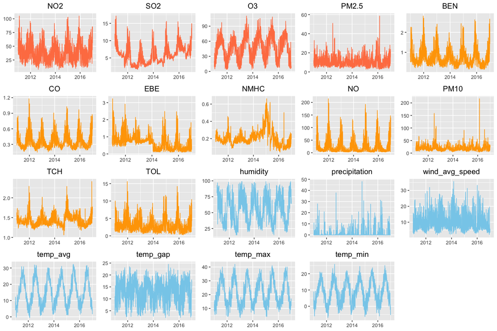

*Dark Orange = Main Pollutants | Light Orange = Other Pollutants | Blue = Weather Parameters*

We can see a cyclic evolution following the seasons, which suggests that the weather has an influence on the level of some pollutants.

## Correlation Matrix

To identify correlations between the variables, we firstly plot a correlation matrix:

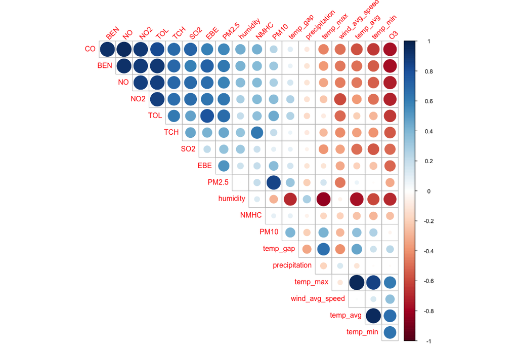

Another view provides more information:

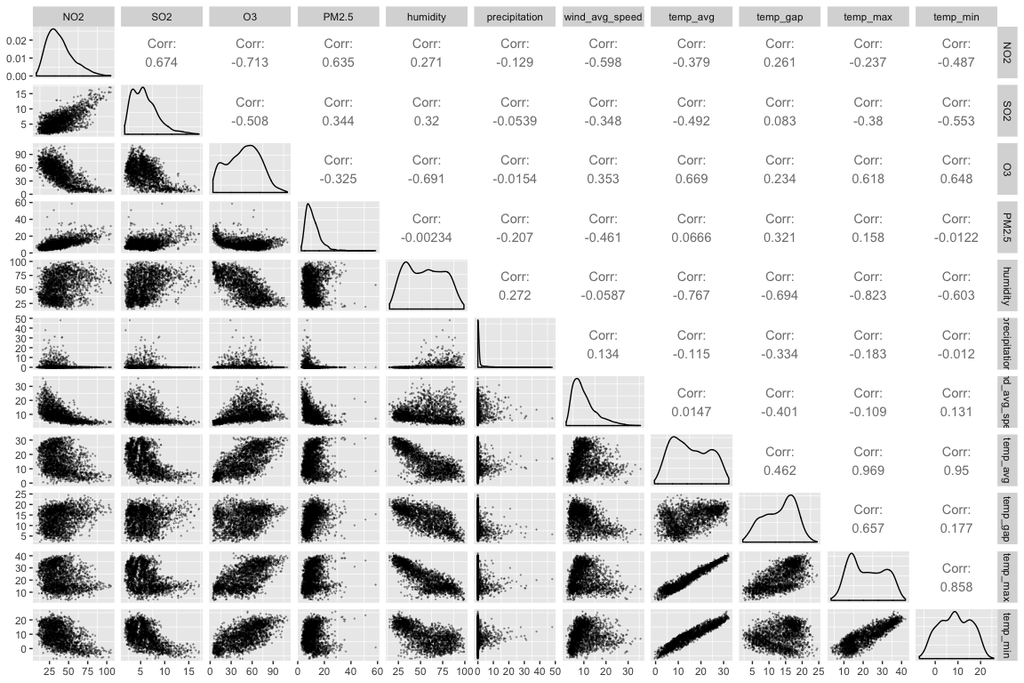

## NO2 Linear Correlation

First we split the data in train and test (80% - 20%).

```r
set.seed(2018)
train.size <- 0.8
train.index <- sample.int(length(pollution_daily_h$NO2), round(length(pollution_daily_h$NO2) * train.size))
train.sample <- pollution_daily_h[train.index,]
test.sample <- pollution_daily_h[-train.index,]
```

The **Train Sample has 1754 rows** and the **Test Sample has 438 rows**.

We want to define a *multilinear regression model* in order to explain NO2 with the rest of the variables. By definition, temp_min and temp_max are correlated with temp_avg, so we remove them.We use the variable *temp_gap* to measure their influence on the model.

```r
multi_model_NO2<-lm(NO2~.-month-week-date-temp_min-temp_max, data=train.sample)
lm_stats <- summary(multi_model_NO2)
print(lm_stats)
```

```
##
## Call:
## lm(formula = NO2 ~ . - month - week - date - temp_min - temp_max,
##     data = train.sample)
##
## Residuals:
##      Min       1Q   Median       3Q      Max
## -21.9368  -3.1235   0.0047   3.2157  21.3306
##
## Coefficients:
##                 Estimate Std. Error t value Pr(>|t|)
## (Intercept)     1.229319   3.113391   0.395 0.693003
## SO2             1.383111   0.077489  17.849  < 2e-16 ***
## O3             -0.149220   0.012032 -12.402  < 2e-16 ***
## PM2.5           0.255679   0.067646   3.780 0.000162 ***
## BEN             3.343452   1.165812   2.868 0.004182 **
## CO             45.100966   3.957109  11.397  < 2e-16 ***
## EBE             2.843966   0.553288   5.140 3.06e-07 ***
## NMHC            1.358368   1.981506   0.686 0.493105
## NO             -0.201584   0.017344 -11.623  < 2e-16 ***
## PM10           -0.008354   0.024343  -0.343 0.731516
## TCH            11.070151   1.621469   6.827 1.19e-11 ***
## TOL             2.850827   0.214695  13.279  < 2e-16 ***
## temp_avg       -0.122812   0.038525  -3.188 0.001459 **
## precipitation   0.178564   0.041030   4.352 1.43e-05 ***
## humidity       -0.098214   0.015546  -6.318 3.36e-10 ***
## wind_avg_speed -0.323058   0.032912  -9.816  < 2e-16 ***
## temp_gap        0.304426   0.053019   5.742 1.10e-08 ***
## ---
## Signif. codes:  0 '***' 0.001 '**' 0.01 '*' 0.05 '.' 0.1 ' ' 1
##
## Residual standard error: 5.096 on 1737 degrees of freedom
## Multiple R-squared:  0.9113, Adjusted R-squared:  0.9105
## F-statistic:  1116 on 16 and 1737 DF,  p-value: < 2.2e-16
```

- As we can see our **R-square value is 0.9113273** and the **Adj.R-squared is 0.9105105**, which means our model is able to explain NO2 well.
- Particularly, this value means that predictors explain **0.9113273 of the variability** in NO2.This could possibly be improved if there is one or more predictors that aren’t very good and are hurting our model.
- One thing to note though is that comparing R-squared values is not a great way of deciding which model is better than the other.

Another thing to look at is the *confidence intervals* for our coefficients. Our estimates for each coefficient are not exact so we want to find a range where we are at a certain percent confident that the actual value is in this range . We can interpret this like: for every change of one (1) unit in the **SO2**, we are **95% confident** that the **NO2 will change between 1.2311291, 1.5350938**.

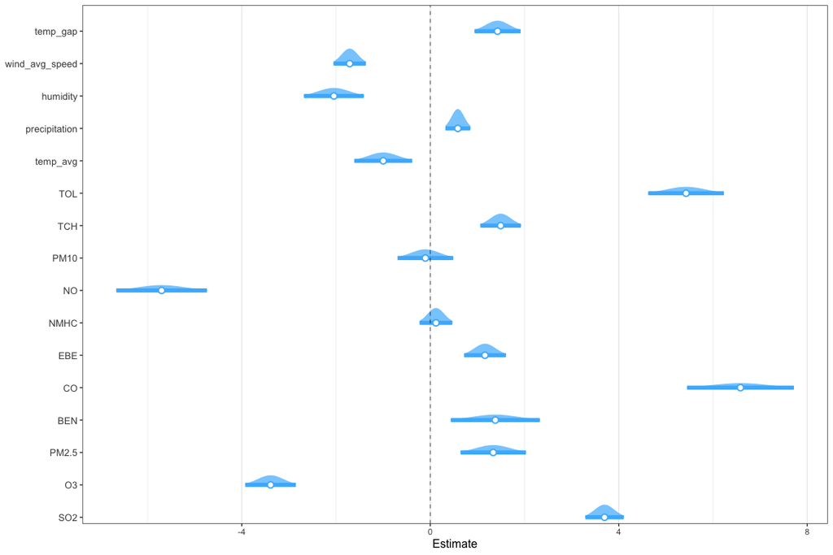

Another important thing is to investigate is if the *assumptions* regarding linear regression are valid. This can be observed by creating the below 4 plots.

```r
resids_multi_NO2 <- multi_model_NO2$residuals
```

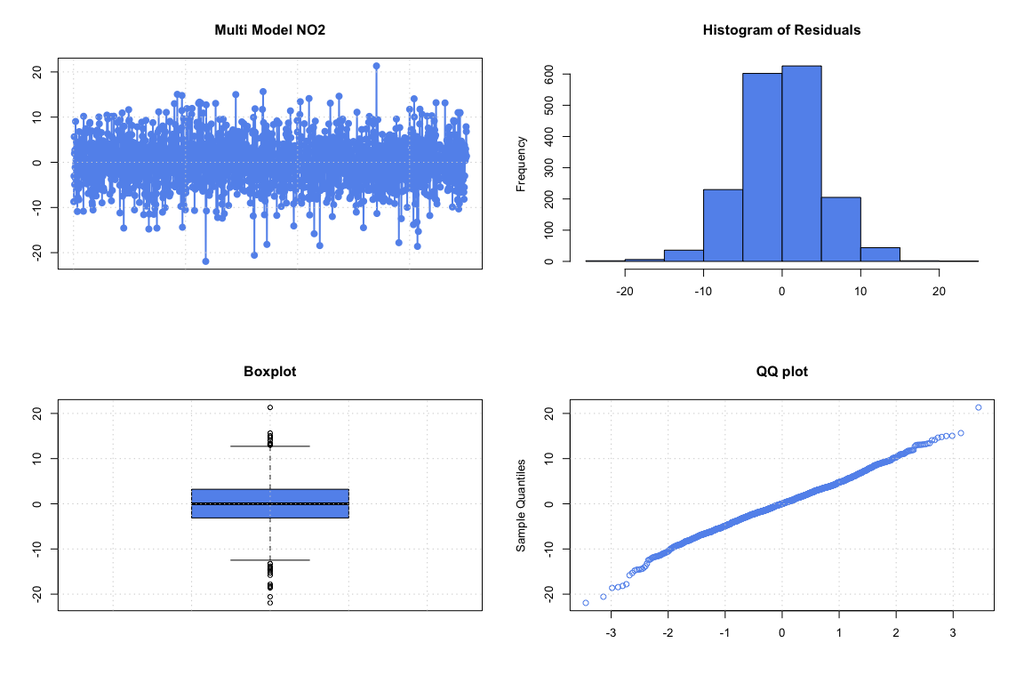

After this analysis, lets see if making some transformations may be beneficial to our model. First, we implement *stepwise regression* to find out the significance in variables.

```
## Start:  AIC=5729.65
## NO2 ~ (date + SO2 + O3 + PM2.5 + BEN + CO + EBE + NMHC + NO +
##     PM10 + TCH + TOL + month + week + temp_avg + temp_max + temp_min +
##     precipitation + humidity + wind_avg_speed + temp_gap) - month -
##     week - date - temp_min - temp_max
##
##                  Df Sum of Sq   RSS    AIC
## - PM10            1       3.1 45114 5727.8
## - NMHC            1      12.2 45124 5728.1
## <none>                        45111 5729.7
## - BEN             1     213.6 45325 5735.9
## - temp_avg        1     263.9 45375 5737.9
## - PM2.5           1     371.0 45482 5742.0
## - precipitation   1     491.9 45603 5746.7
## - EBE             1     686.2 45798 5754.1
## - temp_gap        1     856.2 45968 5760.6
## - humidity        1    1036.6 46148 5767.5
## - TCH             1    1210.5 46322 5774.1
## - wind_avg_speed  1    2502.4 47614 5822.3
## - CO              1    3373.7 48485 5854.2
## - NO              1    3508.4 48620 5859.0
## - O3              1    3994.5 49106 5876.5
## - TOL             1    4579.1 49691 5897.2
## - SO2             1    8274.0 53385 6023.0
##
## Step:  AIC=5727.77
## NO2 ~ SO2 + O3 + PM2.5 + BEN + CO + EBE + NMHC + NO + TCH + TOL +
##     temp_avg + precipitation + humidity + wind_avg_speed + temp_gap
##
##                  Df Sum of Sq   RSS    AIC
## - NMHC            1      11.8 45126 5726.2
## <none>                        45114 5727.8
## + PM10            1       3.1 45111 5729.7
## - BEN             1     226.7 45341 5734.6
## - temp_avg        1     268.4 45383 5736.2
## - precipitation   1     489.2 45604 5744.7
## - EBE             1     684.2 45799 5752.2
## - temp_gap        1     860.1 45974 5758.9
## - PM2.5           1    1026.3 46141 5765.2
## - humidity        1    1067.1 46181 5766.8
```

[output cut: 15 more lines]

```
## + PM10            1       2.6 45124 5728.1
## - BEN             1     219.7 45346 5732.7
## - temp_avg        1     285.4 45412 5735.3
## - precipitation   1     493.7 45620 5743.3
## - EBE             1     674.1 45800 5750.2
## - temp_gap        1     863.8 45990 5757.5
## - PM2.5           1    1015.2 46141 5763.2
## - humidity        1    1089.1 46215 5766.1
## - TCH             1    2061.8 47188 5802.6
## - wind_avg_speed  1    2568.7 47695 5821.3
## - NO              1    3616.4 48743 5859.4
## - CO              1    3638.7 48765 5860.2
## - O3              1    4133.0 49259 5877.9
## - TOL             1    4701.8 49828 5898.1
## - SO2             1    8611.7 53738 6030.6
```

```
## Stepwise Model Path
## Analysis of Deviance Table
##
## Initial Model:
## NO2 ~ (date + SO2 + O3 + PM2.5 + BEN + CO + EBE + NMHC + NO +
##     PM10 + TCH + TOL + month + week + temp_avg + temp_max + temp_min +
##     precipitation + humidity + wind_avg_speed + temp_gap) - month -
##     week - date - temp_min - temp_max
##
## Final Model:
## NO2 ~ SO2 + O3 + PM2.5 + BEN + CO + EBE + NO + TCH + TOL + temp_avg +
##     precipitation + humidity + wind_avg_speed + temp_gap
##
##
##     Step Df  Deviance Resid. Df Resid. Dev      AIC
## 1                          1737   45111.36 5729.651
## 2 - PM10  1  3.058383      1738   45114.42 5727.770
## 3 - NMHC  1 11.762300      1739   45126.18 5726.227
```

Based on the above mentioned results, we get the following formula and the variables removed should be PM10 and NMHC. So, we create the model.

We can still notice a really high R-squared of value 0.9112981. After that, we want to treat **multicollinearity** with the **VIF Method** (variance inflation factors).

As a general rule, if VIF is larger than 5, then multi collinearity is assumed to be high. So,by starting with all the variables in the model, we are going to * calculate the VIF values, * remove the biggest one, * re-do the model until all the explanatory variables have a VIF below 5.

For practicallity we decided to handle the above procedure with a **WHILE loop**.

```r
 selectedMod <- step_0

 all_vifs <- car::vif(selectedMod)
 print('VIF Values of our Initial Explanatory Variables:')
```

```
## [1] "VIF Values of our Initial Explanatory Variables:"
```

```r
 print(all_vifs)
```

```
##            SO2             O3          PM2.5            BEN             CO
##       2.731960       4.737638       2.589103      15.175970      21.433198
##            EBE             NO            TCH            TOL       temp_avg
##       3.384605      15.882579       2.124477      11.084651       6.505867
##  precipitation       humidity wind_avg_speed       temp_gap
##       1.218099       6.663257       1.991433       4.170651
```

```r
 signif_all <- names(all_vifs)

 while(any(all_vifs > 5)){
   var_with_max_vif <- names(which(all_vifs == max(all_vifs)))                       # get the variable with max vif
   signif_all <- signif_all[!(signif_all) %in% var_with_max_vif]                     # re  move this variable
   myForm <- as.formula(paste("NO2~ ", paste (signif_all, collapse=" + "), sep=""))  # design the new formula
   selectedMod <- lm(myForm, data=train.sample)                                     # re-build model with new formula
   all_vifs <- car::vif(selectedMod)
 }

 print('VIF Values of our Final Explanatory Variables:')
```

```
## [1] "VIF Values of our Final Explanatory Variables:"
```

```r
 print(all_vifs)
```

```
##            SO2             O3          PM2.5            EBE            TCH
##       1.958788       3.351606       2.049109       1.829030       1.781684
##       temp_avg  precipitation wind_avg_speed       temp_gap
##       3.056575       1.154820       1.743077       2.058636
```

So our **Final Model** after removing the multicollinear variables is

```
## NO2 ~ SO2 + O3 + PM2.5 + EBE + TCH + temp_avg + precipitation +
##     wind_avg_speed + temp_gap
```

```
##
## Call:
## lm(formula = NO2 ~ SO2 + O3 + PM2.5 + EBE + TCH + temp_avg +
##     precipitation + wind_avg_speed + temp_gap, data = train.sample)
##
## Residuals:
##      Min       1Q   Median       3Q      Max
## -21.9354  -4.1242   0.1759   3.9862  18.8808
##
## Coefficients:
##                Estimate Std. Error t value Pr(>|t|)
## (Intercept)    -1.34165    2.32129  -0.578   0.5634
## SO2             1.70825    0.07619  22.421  < 2e-16 ***
## O3             -0.23205    0.01174 -19.774  < 2e-16 ***
## PM2.5           0.56677    0.03988  14.213  < 2e-16 ***
## EBE             8.34368    0.48211  17.307  < 2e-16 ***
## TCH            17.17983    1.44013  11.929  < 2e-16 ***
## temp_avg       -0.13117    0.03131  -4.189 2.94e-05 ***
## precipitation   0.14279    0.04770   2.993   0.0028 **
## wind_avg_speed -0.35111    0.03630  -9.672  < 2e-16 ***
## temp_gap        0.77269    0.04452  17.355  < 2e-16 ***
## ---
## Signif. codes:  0 '***' 0.001 '**' 0.01 '*' 0.05 '.' 0.1 ' ' 1
##
## Residual standard error: 6.095 on 1744 degrees of freedom
## Multiple R-squared:  0.8727, Adjusted R-squared:  0.872
## F-statistic:  1328 on 9 and 1744 DF,  p-value: < 2.2e-16
```

Let’s see what a **10-Fold Cross validation** will tell us about our model:

```
## [1] "INITIAL MODEL:"
```

```
## Linear Regression
##
## 1754 samples
##   21 predictor
##
## Pre-processing: centered (16), scaled (16)
## Resampling: Cross-Validated (10 fold)
## Summary of sample sizes: 1578, 1579, 1579, 1579, 1578, 1579, ...
## Resampling results:
##
##   RMSE     Rsquared   MAE
##   5.13777  0.9079525  3.97799
##
## Tuning parameter 'intercept' was held constant at a value of TRUE
```

```
## [1] "FINAL MODEL:"
```

```
## Linear Regression
##
## 1754 samples
##    9 predictor
##
## Pre-processing: centered (9), scaled (9)
## Resampling: Cross-Validated (10 fold)
## Summary of sample sizes: 1578, 1578, 1579, 1579, 1578, 1578, ...
## Resampling results:
##
##   RMSE      Rsquared   MAE
##   6.112716  0.8716267  4.866125
##
## Tuning parameter 'intercept' was held constant at a value of TRUE
```

Let’s have a look at the **predictions** for both models

```r
test.sample$NO2_predicted_model_final <- predict(multi_model_NO2_final,test.sample)
test.sample$NO2_predicted_model_0 <- predict(multi_model_NO2_0,test.sample)
```

We show randomly rows 80-90 of the results. We can see that in some cases the original model is better, but also the other way around.

```
##          NO2 NO2_predicted_model_0 NO2_predicted_model_final
## 428 32.90278              33.47543                  38.52169
## 436 41.62434              45.47223                  48.86567
## 438 66.43728              62.02274                  58.57356
## 441 37.94618              36.13524                  35.07174
## 443 20.01215              21.83412                  21.85867
## 447 58.33043              54.81361                  52.00605
## 464 35.96528              37.69067                  40.09754
## 470 18.65799              15.89007                  17.62860
## 482 28.10417              21.46581                  22.55336
## 489 45.54340              37.47732                  37.65892
## 490 31.50521              22.42451                  23.59314
```

Let’s **visualize** it:

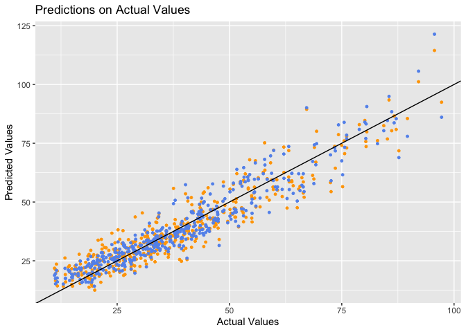

*Blue = Initial Model | Orange = Final Model*

Now lets compare the 2 **models** (initial and final):

```
## Analysis of Variance Table
##
## Model 1: NO2 ~ (date + SO2 + O3 + PM2.5 + BEN + CO + EBE + NMHC + NO +
##     PM10 + TCH + TOL + month + week + temp_avg + temp_max + temp_min +
##     precipitation + humidity + wind_avg_speed + temp_gap) - month -
##     week - date - temp_min - temp_max - PM10 - NMHC
## Model 2: NO2 ~ SO2 + O3 + PM2.5 + EBE + TCH + temp_avg + precipitation +
##     wind_avg_speed + temp_gap
##   Res.Df   RSS Df Sum of Sq      F    Pr(>F)
## 1   1739 45126
## 2   1744 64788 -5    -19661 151.54 < 2.2e-16 ***
## ---
## Signif. codes:  0 '***' 0.001 '**' 0.01 '*' 0.05 '.' 0.1 ' ' 1
```

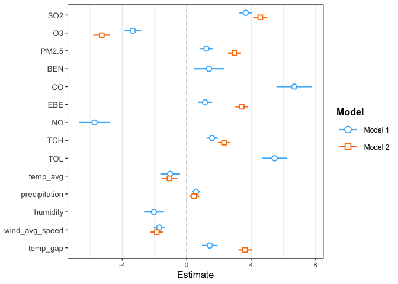